# Mapping Traffic Violations Data NYC

Kagen Lim

2021-03-19

# Parking Violations in NYC

## Data

For this assignment, we are going to investigate data on parking violations in NYC.

#### Parking violations in 2020/21

NYC Open Data has data on all [parking violations issued in NYC](https://data.cityofnewyork.us/City-Government/Parking-Violations-Issued-Fiscal-Year-2021/pvqr-7yc4) since 2014. The updated dataset provided for 2021 currently includes about 10 million observations. To make the assignment manageable, I have reduced it to a subset of tickets issued in from Jan 2020 to Jan 2021 and by Manhattan precincts only, yielding about 2.2M tickets.

Two support files are also included in the `parking` sub folder:

- the **descriptions of all variables**
- the **dictionary of violation codes**

#### Police Precincts

A second data source is the [shape files of police precincts in NYC](https://www1.nyc.gov/site/planning/data-maps/open-data/districts-download-metadata.page).

## Exercise

##### 1. Data exploration

Before focusing on the spatial part of the data, let’s explore the basic patterns in the data.

```r
df <- read.csv('./data/parking/parkingNYC_Jan2020-Jan2021.csv')
```

```r
library(tibble)
glimpse(df)
```

```
## Rows: 2,244,505
## Columns: 47
## $ Summons.Number                    <dbl> 1474094223, 1474094600, 1474097807,…
## $ Plate.ID                          <chr> "KDT3875", "GTW5034", "JEF4856", "H…
## $ Registration.State                <chr> "NY", "NY", "NY", "NY", "PA", "PA",…
## $ Plate.Type                        <chr> "PAS", "PAS", "PAS", "PAS", "PAS", …
## $ Issue.Date                        <chr> "06/24/2020", "06/26/2020", "06/26/…
## $ Violation.Code                    <int> 98, 20, 20, 14, 20, 40, 46, 40, 46,…
## $ Vehicle.Body.Type                 <chr> "SDN", "SDN", "SDN", "SDN", "SUBN",…
## $ Vehicle.Make                      <chr> "KIA", "VOLKS", "ME/BE", "TOYOT", "…
## $ Issuing.Agency                    <chr> "P", "P", "P", "P", "P", "P", "P", …
## $ Street.Code1                      <int> 0, 18390, 35710, 15710, 35930, 3593…
## $ Street.Code2                      <int> 40404, 10110, 15710, 35710, 11710, …
## $ Street.Code3                      <int> 40404, 10010, 11710, 35770, 13610, …
## $ Vehicle.Expiration.Date           <int> 20200805, 20201006, 20201219, 0, 0,…
```

[output cut: 34 more lines]

```r
length(unique(df$Violation.Code))
```

```
## [1] 87
```

##### a) Violation Code and Fine Amounts

Add the violation code descriptions and fine amounts to the data file. Provide a visual overview of the top 10 most common types of violations (feel free to group them into categories if reasonable). Compare how this ranking differs if we focus on the total amount of revenue generated.

```r
library(readxl)
violation_labels <- read_excel('./data/parking/ParkingViolationCodes_January2020.xlsx')

library(tidyverse)
violation_labels <- violation_labels %>%
  rename(
    'Violation.Code' = 'VIOLATION CODE',
    'Violation.Description' = 'VIOLATION DESCRIPTION',
    'Manhattan.Below' = 'Manhattan  96th St. & below\r\n(Fine Amount $)',
    'All.Other.Areas' = 'All Other Areas\r\n(Fine Amount $)'
  )

glimpse(violation_labels)
```

```
## Rows: 97
## Columns: 4
## $ Violation.Code        <dbl> 1, 2, 3, 4, 5, 6, 7, 8, 9, 10, 11, 12, 13, 14, …
## $ Violation.Description <chr> "FAILURE TO DISPLAY BUS PERMIT", "NO OPERATOR N…
## $ Manhattan.Below       <dbl> 515, 515, 515, 115, 50, 265, 50, 115, 115, 115,…
## $ All.Other.Areas       <dbl> 515, 515, 515, 115, 50, 265, 50, 115, 115, 115,…
```

```r
df_violations = merge(x = df, y = violation_labels, by = 'Violation.Code')

glimpse(df_violations)
```

```
## Rows: 2,244,045
## Columns: 50
## $ Violation.Code                    <int> 1, 1, 1, 1, 1, 1, 1, 1, 1, 1, 1, 1,…
## $ Summons.Number                    <dbl> 8773725183, 8696246354, 8773720630,…
## $ Plate.ID                          <chr> "OYB5181", "OYB1400", "OYB5237", "O…
## $ Registration.State                <chr> "NJ", "NJ", "NJ", "NJ", "NJ", "NJ",…
## $ Plate.Type                        <chr> "PAS", "PAS", "PAS", "PAS", "PAS", …
## $ Issue.Date                        <chr> "11/24/2020", "09/25/2020", "10/21/…
## $ Vehicle.Body.Type                 <chr> "BUS", "BUS", "BUS", "BUS", "BUS", …
## $ Vehicle.Make                      <chr> "FORD", "FORD", "FORD", "FORD", "FO…
## $ Issuing.Agency                    <chr> "T", "T", "T", "T", "T", "T", "T", …
## $ Street.Code1                      <int> 10810, 34610, 10810, 10810, 10810, …
## $ Street.Code2                      <int> 0, 10810, 0, 0, 0, 10810, 0, 0, 345…
## $ Street.Code3                      <int> 0, 10910, 0, 0, 0, 10910, 0, 0, 345…
## $ Vehicle.Expiration.Date           <int> 88880088, 88880088, 88880088, 88880…
```

[output cut: 37 more lines]

```r
length(unique(df_violations$Violation.Description.y))
```

```
## [1] 85
```

```r
length(unique(df_violations$Violation.Code))
```

```
## [1] 85
```

```r
#Both are 85. We are good to go.

colnames(df_violations)
```

```
##  [1] "Violation.Code"                    "Summons.Number"
##  [3] "Plate.ID"                          "Registration.State"
##  [5] "Plate.Type"                        "Issue.Date"
##  [7] "Vehicle.Body.Type"                 "Vehicle.Make"
##  [9] "Issuing.Agency"                    "Street.Code1"
## [11] "Street.Code2"                      "Street.Code3"
## [13] "Vehicle.Expiration.Date"           "Violation.Location"
## [15] "Violation.Precinct"                "Issuer.Precinct"
## [17] "Issuer.Code"                       "Issuer.Command"
## [19] "Issuer.Squad"                      "Violation.Time"
## [21] "Time.First.Observed"               "Violation.County"
## [23] "Violation.In.Front.Of.Or.Opposite" "House.Number"
## [25] "Street.Name"                       "Intersecting.Street"
## [27] "Date.First.Observed"               "Law.Section"
## [29] "Sub.Division"                      "Violation.Legal.Code"
## [31] "Days.Parking.In.Effect"            "From.Hours.In.Effect"
## [33] "To.Hours.In.Effect"                "Vehicle.Color"
## [35] "Unregistered.Vehicle."             "Vehicle.Year"
## [37] "Meter.Number"                      "Feet.From.Curb"
## [39] "Violation.Post.Code"               "Violation.Description.x"
## [41] "No.Standing.or.Stopping.Violation" "Hydrant.Violation"
## [43] "Double.Parking.Violation"          "issue_date"
## [45] "year"                              "month"
## [47] "day"                               "Violation.Description.y"
## [49] "Manhattan.Below"                   "All.Other.Areas"
```

```r
violations_count <- as.data.frame( table(df_violations$Violation.Description.y) )

violations_top10 <- violations_count %>%
  arrange (desc(Freq)) %>%
  head(11)

violations_top10
```

```
##                              Var1   Freq
## 1     NO STANDING-DAY/TIME LIMITS 296962
## 2      NO PARKING-DAY/TIME LIMITS 271285
## 3  FAIL TO DSPLY MUNI METER RECPT 201108
## 4     NO STANDING-COMM METER ZONE 180219
## 5      NO PARKING-STREET CLEANING 161910
## 6                  DOUBLE PARKING 139444
## 7  FAIL TO DISP. MUNI METER RECPT 131976
## 8                    FIRE HYDRANT 122162
## 9  NO STANDING-EXC. TRUCK LOADING 100093
## 10             EXPIRED MUNI METER  70944
## 11   DOUBLE PARKING-MIDTOWN COMML  66101
```

```r
violations_top10[violations_top10$Var1 == "FAIL TO DSPLY MUNI METER RECPT", ] <- violations_top10[violations_top10$Var1 == "FAIL TO DSPLY MUNI METER RECPT", ] + violations_top10[violations_top10$Var1 == "FAIL TO DISP. MUNI METER RECPT", ]
violations_top10 <- violations_top10[rownames(violations_top10) != 7, ]

violations_top10[3, 1] = "FAIL TO DSPLY MUNI METER RECPT"

violations_top10$Var1 <- factor(violations_top10$Var1, levels = violations_top10$Var1[order(violations_top10$Freq, decreasing = F)])

levels(violations_top10$Var1)
```

```
##  [1] "DOUBLE PARKING-MIDTOWN COMML"   "EXPIRED MUNI METER"
##  [3] "NO STANDING-EXC. TRUCK LOADING" "FIRE HYDRANT"
##  [5] "DOUBLE PARKING"                 "NO PARKING-STREET CLEANING"
##  [7] "NO STANDING-COMM METER ZONE"    "NO PARKING-DAY/TIME LIMITS"
##  [9] "NO STANDING-DAY/TIME LIMITS"    "FAIL TO DSPLY MUNI METER RECPT"
```

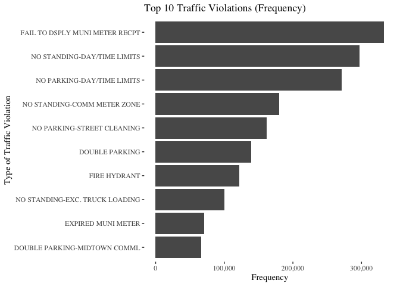

```r
library(ggplot2)
library(ggthemes)
count_compare <- ggplot(violations_top10, aes(x= Var1, y = Freq)) +
  geom_bar(stat = 'identity') +
  coord_flip() +
  scale_y_continuous(name="Frequency", labels = scales::comma) +
  scale_x_discrete(name = "Type of Traffic Violation") +
  labs(title = "Top 10 Traffic Violations (Frequency)") +
  theme_tufte()

count_compare
```

```r
violations_fine_top10 <- df_violations %>%
  group_by(Violation.Description.y) %>%
  summarise(total_fine = sum(Manhattan.Below)) %>%
  arrange (desc(total_fine))  %>%
  head(11)
violations_fine_top10[violations_fine_top10$Violation.Description.y == "FAIL TO DSPLY MUNI METER RECPT", "total_fine"] <- violations_fine_top10[violations_fine_top10$Violation.Description.y == "FAIL TO DSPLY MUNI METER RECPT", "total_fine"] + violations_fine_top10[violations_fine_top10$Violation.Description.y == "FAIL TO DISP. MUNI METER RECPT", "total_fine"]

violations_fine_top10 <- violations_fine_top10[rownames(violations_fine_top10) != 9, ]

violations_fine_top10
```

```
## # A tibble: 10 x 2
##    Violation.Description.y        total_fine
##    <chr>                               <dbl>
##  1 NO STANDING-DAY/TIME LIMITS      34150630
##  2 NO STANDING-COMM METER ZONE      20725185
##  3 NO PARKING-DAY/TIME LIMITS       17633525
##  4 DOUBLE PARKING                   16036060
##  5 FIRE HYDRANT                     14048630
##  6 FAIL TO DSPLY MUNI METER RECPT   21650460
##  7 NO PARKING-STREET CLEANING       10524150
##  8 NO STANDING-EXC. TRUCK LOADING    9508835
##  9 DOUBLE PARKING-MIDTOWN COMML      7601615
## 10 NO STANDING-BUS STOP              7463270
```

```r
violations_fine_top10$Violation.Description.y <- factor(violations_fine_top10$Violation.Description.y, levels = violations_fine_top10$Violation.Description.y[order(violations_fine_top10$total_fine, decreasing = F)])

levels(violations_fine_top10$Violation.Description.y)
```

```
##  [1] "NO STANDING-BUS STOP"           "DOUBLE PARKING-MIDTOWN COMML"
##  [3] "NO STANDING-EXC. TRUCK LOADING" "NO PARKING-STREET CLEANING"
##  [5] "FIRE HYDRANT"                   "DOUBLE PARKING"
##  [7] "NO PARKING-DAY/TIME LIMITS"     "NO STANDING-COMM METER ZONE"
##  [9] "FAIL TO DSPLY MUNI METER RECPT" "NO STANDING-DAY/TIME LIMITS"
```

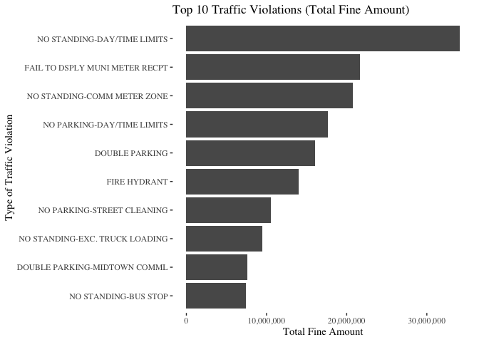

```r
library(ggplot2)

fine_compare <- ggplot(violations_fine_top10, aes(x= Violation.Description.y, y = total_fine)) +
  geom_col() +
  coord_flip() +
  scale_y_continuous(name="Total Fine Amount", labels = scales::comma) +
  scale_x_discrete(name = "Type of Traffic Violation") +
  labs(title = "Top 10 Traffic Violations (Total Fine Amount)") +
  theme_tufte()

fine_compare
```

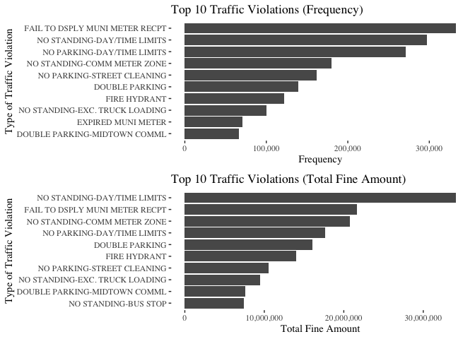

```r
library(ggpubr)
ggarrange(count_compare, fine_compare, nrow = 2)
```

There are some overlaps between the frequency of top traffic violations, and their associated fine amounts.

##### b) Average amount of fine by vehicle

Compare the average amount of fine by vehicle color, vehicle year, and [vehicle plate type](https://dmv.ny.gov/registration/registration-class-codes) [Hint: it is sufficient to restrict your attention to commercial (`COM`) and passenger (`PAS`) vehicles]? Briefly describe your findings.

```r
violations_fine_color <- df_violations %>%
  group_by(Vehicle.Color) %>%
  summarise(mean_fine = mean(Manhattan.Below)) %>%
  arrange (desc(mean_fine))
max(violations_fine_color$mean_fine)
```

```
## [1] 180
```

```r
min(violations_fine_color$mean_fine)
```

```
## [1] 32.5
```

```r
unique(violations_fine_color$mean_fine)
```

```
##   [1] 180.00000 165.00000 130.00000 115.00000 114.09091 113.66667 112.16450
##   [8] 112.08333 111.02273 110.22876 109.16667 108.33333 108.28571 107.71505
##  [15] 106.66667 106.61290 105.90909 105.71429 105.21739 105.00000 104.78261
##  [22] 104.76190 104.00000 103.50000 103.14713 102.89704 102.53846 102.50000
##  [29] 102.38785 101.78212 101.66948 101.53846 100.99068 100.40052 100.31250
##  [36] 100.00000  98.68421  98.33333  97.90155  97.85714  97.83333  97.55222
##  [43]  97.48092  97.10145  96.12299  96.08974  95.53571  95.00000  94.92554
##  [50]  94.44999  94.11501  94.11040  94.00000  93.52941  93.28571  92.97209
##  [57]  92.96512  92.70717  92.50000  92.05682  91.66667  91.60920  91.25000
##  [64]  91.14480  90.97594  90.96491  90.68260  90.48970  90.45764  90.28698
##  [71]  90.00000  89.39566  88.92308  88.83606  88.47694  88.18328  87.75272
##  [78]  87.50000  87.43902  86.66667  86.59620  86.58625  86.04244  85.98214
##  [85]  85.89286  85.78890  85.42443  85.33422  85.00000  84.75856  84.52457
##  [92]  84.36508  84.23469  84.08111  84.04412  83.89937  83.88541  83.33333
##  [99]  81.93182  81.73469  81.66667  80.66667  80.00000  77.50000  77.17391
## [106]  69.48980  65.00000  32.50000
```

```r
#rough segmentation - 32.5 to 90, 90 to 100, 100 to 180#

violations_fine_color$groups = ifelse(violations_fine_color$mean_fine <=90, 'Low Fine Amt', 0)

violations_fine_color$groups = ifelse(violations_fine_color$mean_fine >90 & violations_fine_color$mean_fine<=100, 'Medium Fine Amt', violations_fine_color$groups)

violations_fine_color$groups = ifelse(violations_fine_color$mean_fine >100, 'High Fine Amt', violations_fine_color$groups)

violations_fine_color$groups <- as.factor(violations_fine_color$groups)

violations_fine_color %>% #simple counts of each category
  group_by(groups) %>%
  count()
```

```
## # A tibble: 3 x 2
## # Groups:   groups [3]
##   groups              n
##   <fct>           <int>
## 1 High Fine Amt     106
## 2 Low Fine Amt       85
## 3 Medium Fine Amt    57
```

```r
violations_fine_color_high <- violations_fine_color %>%
  filter(groups == "High Fine Amt")

as.data.frame( table(unique(violations_fine_color_high$Vehicle.Color)) )
```

```
##      Var1 Freq
## 1     B L    1
## 2   BAIGE    1
## 3   BALCK    1
## 4    BBRW    1
## 5    BERG    1
## 6      BG    1
## 7     BGE    1
## 8   BIERG    1
## 9     BKJ    1
## 10   BLAK    1
## 11    BLE    1
## 12    BLK    1
## 13    BLU    1
## 14    BLY    1
```

[output cut: 91 more lines]

```r
violations_fine_color_medium <- violations_fine_color %>%
  filter(groups == "Medium Fine Amt")

as.data.frame( table(unique(violations_fine_color_medium$Vehicle.Color)) )
```

```
##     Var1 Freq
## 1   .  Y    1
## 2      B    1
## 3  BEING    1
## 4  BERGU    1
## 5    BKG    1
## 6   BLAC    1
## 7  BLACK    1
## 8   BLCK    1
## 9   BLUE    1
## 10  BRCH    1
## 11   BUR    1
## 12 BURGE    1
## 13 BURGU    1
## 14  DKGN    1
```

[output cut: 43 more lines]

```r
violations_fine_color_low <- violations_fine_color %>%
  filter(groups == "Low Fine Amt")

as.data.frame( table(unique(violations_fine_color_low$Vehicle.Color)) )
```

```
##     Var1 Freq
## 1     .-    1
## 2  B ACK    1
## 3  B LAC    1
## 4    BCK    1
## 5    BCL    1
## 6   BEGE    1
## 7   BEIG    1
## 8  BEIGE    1
## 9     BI    1
## 10 BIEGE    1
## 11    BK    1
## 12   BK/    1
## 13   BKT    1
## 14   BKW    1
```

[output cut: 71 more lines]

No firm conclusions can be drawn about variation in average fine amounts, according to `Vehicle.Color`, because the data is very unclean. However, it is noteworthy that for `High Fine Amt`, there are many more color types. A preliminary hypothesis that cars with novel colors might be more likely to have committed violations with higher fine amounts. A visual inspection of the tables also show the prevalence of more colors that might not be represented for vehicles that have caused `Medium Fine Amt` and `Low Fine Amt` violations.

```r
violations_fine_year <- df_violations %>%
  group_by(Vehicle.Year) %>%
  summarise(mean_fine = mean(Manhattan.Below)) %>%
  arrange (desc(mean_fine))
min(violations_fine_year$Vehicle.Year) #nonsense
```

```
## [1] 0
```

```r
max(violations_fine_year$Vehicle.Year) #nonsense
```

```
## [1] 2069
```

```r
violations_fine_year <- df_violations %>%
  filter(Vehicle.Year != 0 & Vehicle.Year <=2021) %>%
  group_by(Vehicle.Year) %>%
  summarise(mean_fine = mean(Manhattan.Below)) %>%
  arrange (desc(mean_fine))
```

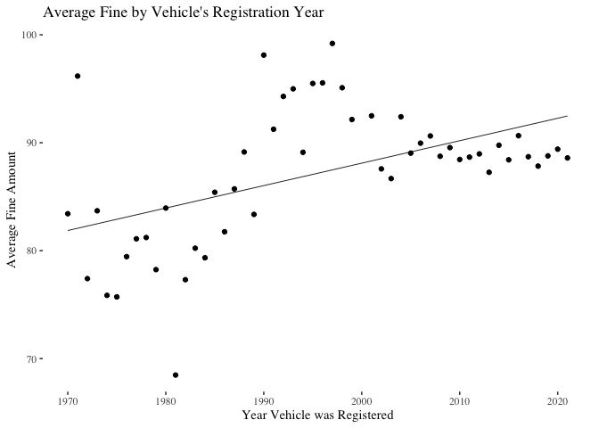

```r
ggplot(violations_fine_year, aes(x=Vehicle.Year, y=mean_fine)) +
  geom_point() +
  stat_smooth(method= "lm", color = "black", se=F, size=0.3) +
  labs(
    x = 'Year Vehicle was Registered',
    y = 'Average Fine Amount',
    title="Average Fine by Vehicle's Registration Year") +
  theme_tufte()
```

The earlier a car is registered, the more likely that the mean fine amount incurred is a smaller value. The later a car is registered, the more likely that the mean fine amount incurred is a higher value.

```r
violations_fine_plate <- df_violations %>%
  group_by(Plate.Type) %>%
  filter (Plate.Type == 'COM' | Plate.Type == 'PAS') %>%
  summarise(mean_fine = mean(Manhattan.Below)) %>%
  arrange (desc(mean_fine))
violations_fine_plate
```

```
## # A tibble: 2 x 2
##   Plate.Type mean_fine
##   <chr>          <dbl>
## 1 COM             91.6
## 2 PAS             89.7
```

```r
violations_fine_plate_foranova <- df_violations %>%
  group_by(Plate.Type) %>%
  filter (Plate.Type == 'COM' | Plate.Type == 'PAS')

violations_fine_plate_foranova$Plate.Type <- as.factor(violations_fine_plate_foranova$Plate.Type)

summary(aov(Manhattan.Below ~ Plate.Type, data = violations_fine_plate_foranova)) #statistically significant difference in fine amounts between Plate.Type#
```

```
##                  Df    Sum Sq Mean Sq F value Pr(>F)
## Plate.Type        1 1.707e+06 1706749    2795 <2e-16 ***
## Residuals   2129696 1.300e+09     611
## ---
## Signif. codes:  0 '***' 0.001 '**' 0.01 '*' 0.05 '.' 0.1 ' ' 1
```

Commercial vehicles (M=91.6) seem to incur, on average, higher fines than passenger vehicles (M=89.7). An exploratory one-way Analysis of Variance (ANOVA) was run to compare the mean fine values of these two groups, and indeed there was a significantly significant difference in fine values (p<.01) between the two groups.

##### c) Effect of COVID

Let’s see if we can observe the effect of COVID restrictions on parking violations. Present a visualization that shows how parking violations changed after the New York statewide stay-at-home order on March 14, 2020. Make sure the visualization clearly highlights the main pattern (the COVID effect).

```r
library(anytime)
df_violations$issue_date <- anytime::anydate(df_violations$issue_date)

glimpse(df_violations$issue_date)
```

```
##  Date[1:2244045], format: "2020-11-24" "2020-09-25" "2020-10-21" "2020-11-24" "2020-08-25" ...
```

```r
df_violations$Month_Yr <- format(as.Date(df_violations$issue_date), "%Y-%m")

glimpse(df_violations$Month_Yr)
```

```
##  chr [1:2244045] "2020-11" "2020-09" "2020-10" "2020-11" "2020-08" ...
```

```r
df_covid <- df_violations %>%
  filter (issue_date >= '2020-01-01') %>%
  count(Month_Yr) %>%
  filter(Month_Yr <= '2021-01')

df_covid
```

```
##    Month_Yr      n
## 1   2020-01     56
## 2   2020-02     19
## 3   2020-03    177
## 4   2020-04     79
## 5   2020-05    143
## 6   2020-06  15053
## 7   2020-07 178563
## 8   2020-08 352658
## 9   2020-09 397106
## 10  2020-10 395206
## 11  2020-11 339235
## 12  2020-12 285292
## 13  2021-01 280408
```

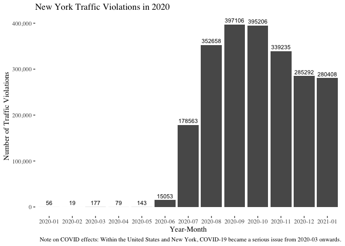

```r
ggplot(df_covid, aes(x = Month_Yr, y = n)) +
  geom_col() +
  geom_text(
    aes(label = n, y = n),
    position = position_dodge(0.2),
    vjust = -0.5,
    size=3
  ) +
  scale_x_discrete(name="Year-Month") +
  scale_y_continuous(name="Number of Traffic Violations", labels = scales::comma) +
  labs(title="New York Traffic Violations in 2020", caption = "Note on COVID effects: Within the United States and New York, COVID-19 became a serious issue from 2020-03 onwards.") +
  theme_tufte()
```

```r
#https://www.nytimes.com/2021/01/05/nyregion/nyc-residential-parking.html #Increase in Car Ownership, post-COVID, as a potential reason for these effects#
```

#### 2. Map by Precincts

Read in the shape files for the police precincts and remove all precincts outside of Manhattan.

```r
library(rgdal)
```

```r
police_prec <- readOGR('/Users/kagenlim/Documents/Data Viz/07_parking-graded/data/police_precincts/nypp.shp')
manhattan_before <- subset(police_prec, Precinct<=34) #only Manhattan
#https://www1.nyc.gov/site/nypd/bureaus/patrol/precincts-landing.page

manhattan_before <- spTransform(manhattan_before, "+init=ESRI:102718")

manhattan <- fortify(manhattan_before)
from = unique(manhattan$id)

to = unique(manhattan_before$Precinct)

map = setNames(to, from)

manhattan$id =  map[manhattan$id]

unique(manhattan$id) #all good#
```

```
##  [1]  1  5  6  7  9 10 13 14 17 18 19 20 22 23 24 25 26 28 30 32 33 34
```

```r
manhattan <- manhattan %>%
  rename(
    Violation.Precinct = id,
    )

manhattan$Violation.Precinct <- as.factor(manhattan$Violation.Precinct)
```

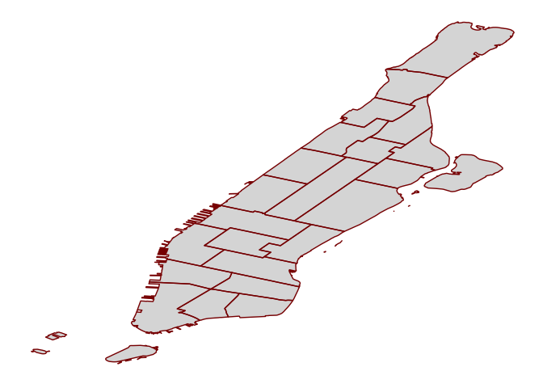

```r
library(ggplot2)
library(ggthemes)
manhattan_poly <- ggplot() +
  geom_polygon(aes(y=lat, x=long, group=group),
               color="dark red", data=manhattan, alpha=.2)  +
  theme_map()

manhattan_poly
```

##### a) Number of tickets, total fines, and average fines

Provide three maps that show choropleth maps of:

- the total number of tickets

```r
violations_prec <- as.data.frame( table(df_violations$Violation.Precinct) )

violations_prec$Var1 <- as.integer(violations_prec$Var1)

manhattan_violations_prec <- subset(violations_prec,as.integer(Var1) <= 34)

manhattan_violations_prec <- manhattan_violations_prec %>%
  rename(
    Violation.Precinct = Var1,
    )

manhattan_violations_prec$Violation.Precinct <- as.factor(manhattan_violations_prec$Violation.Precinct)

manhattan_violations_prec
```

```
##    Violation.Precinct   Freq
## 1                   1    233
## 2                   2 163469
## 3                   3      7
## 4                   4      4
## 5                   5      8
## 6                   6  92813
## 7                   7 125203
## 8                   8  61854
## 9                   9      2
## 10                 10  96271
## 11                 11 124158
## 12                 12      2
## 13                 13 188542
## 14                 14 197335
```

[output cut: 20 more lines]

```r
df_violations_location = left_join(x = manhattan, y = manhattan_violations_prec, by = 'Violation.Precinct')

unique(df_violations_location$Freq)
```

```
##  [1]    233      8  92813 125203      2  96271 188542 197335 207388 271678
## [11] 101313  61823  92080  43054  28600      3  24971  51263
```

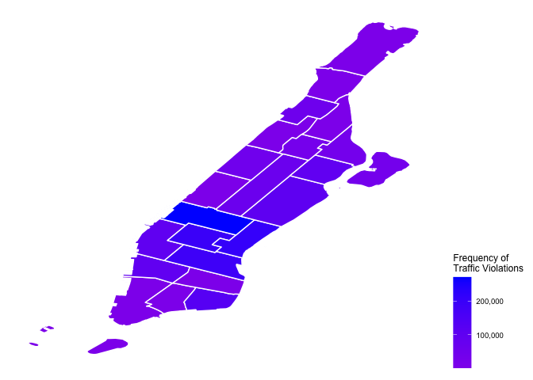

```r
manhattan_poly_n <- ggplot() +
  geom_polygon(aes(fill = Freq, y=lat, x=long, group=group),
               color = 'white', data=df_violations_location) +
  scale_fill_gradient(name="Frequency of \nTraffic Violations", labels = scales::comma, low = "purple2", high = "blue") +
  theme_map() +
  theme(legend.position = 'right')

manhattan_poly_n
```

- the total amount of fines

```r
df_violations_group_fine <- df_violations %>%
  group_by(Violation.Precinct) %>%
  summarize(total_fines_byprec = sum(Manhattan.Below))
manhattan_violations_group_fine <- subset(df_violations_group_fine,as.integer(Violation.Precinct) <= 34)

manhattan_violations_group_fine$Violation.Precinct <- as.factor(manhattan_violations_group_fine$Violation.Precinct)

manhattan_violations_group_fine
```

```
## # A tibble: 31 x 2
##    Violation.Precinct total_fines_byprec
##    <fct>                           <dbl>
##  1 0                               24770
##  2 1                            14698510
##  3 2                                 785
##  4 3                                 410
##  5 4                                 770
##  6 5                             7870865
##  7 6                            10193765
##  8 7                             5123620
##  9 8                                 190
## 10 9                             8284975
## # … with 21 more rows
```

```r
#same as above
manhattan$Violation.Precinct <- as.factor(manhattan$Violation.Precinct)
```

```r
df_violations_fine_location = left_join(x = manhattan, y = manhattan_violations_group_fine, by = 'Violation.Precinct')

unique(df_violations_fine_location$total_fines_byprec)
```

```
##  [1] 14698510  7870865 10193765  5123620  8284975 11215995 16983205 19071685
##  [9] 12553685 20118160 24444130  8764365    15235  5683850  8079715  3754230
## [17]  2494015  6042175  2194665  4202170  4583540  5737010
```

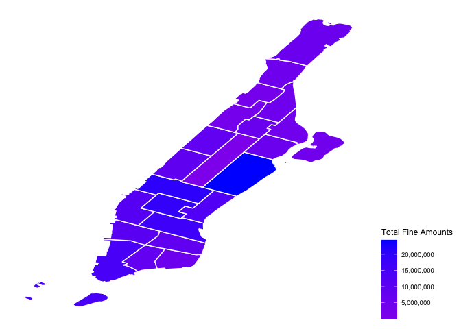

```r
manhattan_poly_fine <- ggplot() +
  geom_polygon(aes(fill = total_fines_byprec, y=lat, x=long, group=group),
               color = 'white', data=df_violations_fine_location) +
  scale_fill_gradient(name="Total Fine Amounts", labels = scales::comma, low = "purple2", high = "blue") +
  theme_map() +
  theme(legend.position = 'right')

manhattan_poly_fine
```

- the average amount of fines

```r
df_violations_group_fine_mean <- df_violations %>%
  group_by(Violation.Precinct) %>%
  summarize(mean_fines_byprec = mean(Manhattan.Below))
manhattan_violations_group_fine_mean <- subset(df_violations_group_fine_mean,as.integer(Violation.Precinct) <= 34)

manhattan_violations_group_fine_mean$Violation.Precinct <- as.factor(manhattan_violations_group_fine_mean$Violation.Precinct)

manhattan_violations_group_fine_mean
```

```
## # A tibble: 31 x 2
##    Violation.Precinct mean_fines_byprec
##    <fct>                          <dbl>
##  1 0                              106.
##  2 1                               89.9
##  3 2                              112.
##  4 3                              102.
##  5 4                               96.2
##  6 5                               84.8
##  7 6                               81.4
##  8 7                               82.8
##  9 8                               95
## 10 9                               86.1
## # … with 21 more rows
```

```r
#same as above
manhattan$Violation.Precinct <- as.factor(manhattan$Violation.Precinct)
```

```r
df_violations_fine_location_mean = left_join(x = manhattan, y = manhattan_violations_group_fine_mean, by = 'Violation.Precinct')

unique(df_violations_fine_location_mean$mean_fines_byprec)
```

```
##  [1] 89.91619 84.80348 81.41790 82.83409 86.05889 90.33647 90.07651 96.64624
##  [9] 98.74450 97.00735 89.97464 86.50780 97.03822 91.93747 87.74669 87.19817
## [17] 87.20332 87.96935 87.88855 92.10437 89.41225 92.61458
```

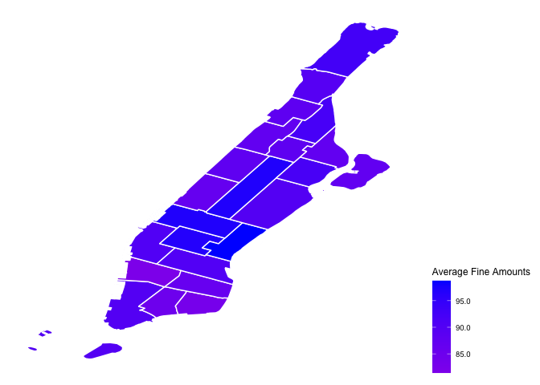

```r
manhattan_poly_avg_fine <- ggplot() +
  geom_polygon(aes(fill = mean_fines_byprec, y=lat, x=long, group=group),
               color = 'white', data=df_violations_fine_location_mean) +
  scale_fill_gradient(name="Average Fine Amounts", labels = scales::comma, low = "purple2", high = "blue") +
  theme_map() +
  theme(legend.position = 'right')

manhattan_poly_avg_fine
```

**Briefly describe what you learn from these maps in comparison.**

```r
ggarrange(manhattan_poly_n,
manhattan_poly_fine,
manhattan_poly_avg_fine, ncol=2,nrow=2)
```

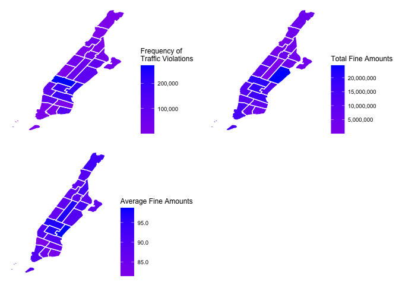

##### b) Types of violations

Group the almost 100 types of ticket violations into a smaller set of 4-6 subgroups (where `other` should be the remainder of violations not included in other groups you defined). [Hint: No need to spend more than 5 minutes thinking about what the right grouping is.]. Provide choropleth maps for each of these subgroups to show where different types of violations are more or less common.

```r
df_violations_manhattan <- subset(df_violations,as.integer(Violation.Precinct) <= 34)

df_violations_parking <- subset(df_violations_manhattan, subset = Violation.Code %in% c(4, 6, 20, 21, 23, 24, 27, 32, 33, 34, 35, 37, 38, 39, 40, 42, 43, 44, 46, 47, 59, 60, 77, 78, 86, 87))

df_violations_standing <- subset(df_violations_manhattan, subset = Violation.Code %in% c(8, 10, 11, 13, 14, 15, 16, 17, 18, 19, 22, 25, 26, 28, 30, 31, 63, 64, 79, 81, 89))

df_violations_inmotion <- subset(df_violations_manhattan, subset = Violation.Code %in% c(5, 7, 9, 12, 36, 45, 48, 49, 50, 51, 52, 53, 55, 56, 57, 58, 61, 96, 98))

df_violations_permits_signs_reg <- subset(df_violations_manhattan, subset = Violation.Code %in% c(1, 2, 29, 65, 70, 71, 72, 73, 74, 75, 76, 83))

df_violations_other <- subset(df_violations_manhattan, subset = Violation.Code %in% c(3, 41, 54, 62, 66, 67, 68, 69, 80, 82, 84, 85, 88, 90, 91, 92, 93, 97, 99))
```

```r
check_rows_manhattan <- nrow(df_violations_manhattan)

check_rows_manhattan
```

```
## [1] 2235621
```

```r
check_rows_grouped <- nrow(df_violations_parking) + nrow(df_violations_standing) + nrow(df_violations_inmotion) + nrow(df_violations_permits_signs_reg) +
nrow(df_violations_other)

check_rows_grouped
```

```
## [1] 2235621
```

```r
check_rows_manhattan == check_rows_grouped
```

```
## [1] TRUE
```

```r
#successfully grouped all observations#
```

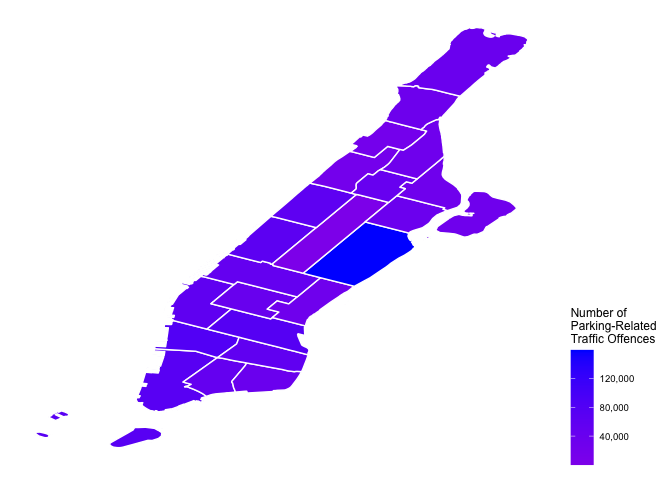

```r
parking_related <- as.data.frame( table(df_violations_parking$Violation.Precinct) )

parking_related_prec <- parking_related %>%
  rename(
    Violation.Precinct = Var1
    )

manhattan_parking = left_join(x = manhattan, y = parking_related_prec, by = 'Violation.Precinct')

manhattan_parking_map <- ggplot() +
  geom_polygon(aes(fill = Freq, y=lat, x=long, group=group),
               color = 'white', data=manhattan_parking) +
  scale_fill_gradient(name="Number of \nParking-Related \nTraffic Offences", labels = scales::comma, low = "purple2", high = "blue") +
  theme_map() +
  theme(legend.position = 'right')


manhattan_parking_map
```

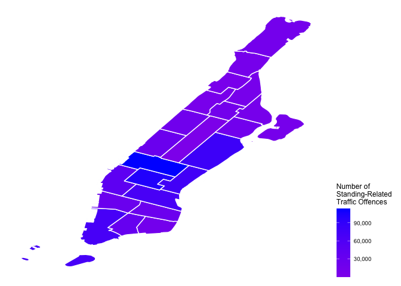

```r
standing_related <- as.data.frame( table(df_violations_standing$Violation.Precinct) )

standing_related_prec <- standing_related %>%
  rename(
     Violation.Precinct = Var1
    )

manhattan_standing = left_join(x = manhattan, y = standing_related_prec, by = 'Violation.Precinct')

manhattan_standing_map <- ggplot() +
  geom_polygon(aes(fill = Freq, y=lat, x=long, group=group),
               color = 'white', data=manhattan_standing) +
  scale_fill_gradient(name="Number of \nStanding-Related \nTraffic Offences", labels = scales::comma, low = "purple2", high = "blue") +
  theme_map() +
  theme(legend.position = 'right')


manhattan_standing_map
```

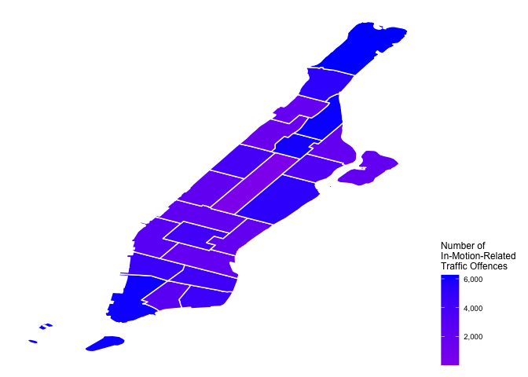

```r
inmotion_related <- as.data.frame( table(df_violations_inmotion$Violation.Precinct) )

inmotion_related_prec <- inmotion_related %>%
  rename(
     Violation.Precinct = Var1
    )

manhattan_inmotion= left_join(x = manhattan, y = inmotion_related_prec, by = 'Violation.Precinct')

manhattan_inmotion_map <- ggplot() +
  geom_polygon(aes(fill = Freq, y=lat, x=long, group=group),
               color = 'white', data=manhattan_inmotion) +
  scale_fill_gradient(name="Number of \nIn-Motion-Related \nTraffic Offences", labels = scales::comma, low = "purple2", high = "blue") +
  theme_map() +
  theme(legend.position = 'right')


manhattan_inmotion_map
```

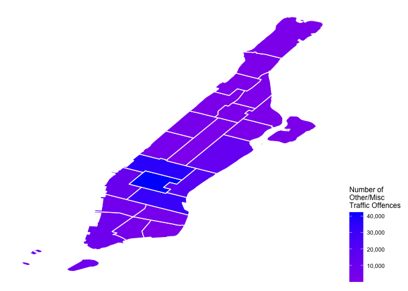

```r
other_related <- as.data.frame( table(df_violations_other$Violation.Precinct) )

other_prec <- other_related %>%
  rename(
     Violation.Precinct = Var1
    )

manhattan_other= left_join(x = manhattan, y = other_prec, by = 'Violation.Precinct')

manhattan_other_map <- ggplot() +
  geom_polygon(aes(fill = Freq, y=lat, x=long, group=group),
               color = 'white', data=manhattan_other) +
  scale_fill_gradient(name="Number of \nOther/Misc \nTraffic Offences", labels = scales::comma, low = "purple2", high = "blue") +
  theme_map() +
  theme(legend.position = 'right')


manhattan_other_map
```

```r
ggarrange(manhattan_parking_map,
manhattan_standing_map,
manhattan_inmotion_map,
manhattan_other_map, ncol=2,nrow=2)
```

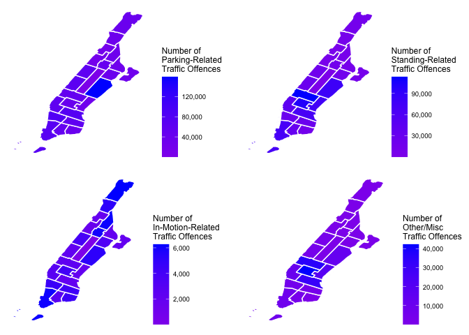

Somewhat unsurprisingly, the number of in-motion related offences are highest in the areas at the tips of Mantattan, Washington Heights and the financial district, where one might expect the highest amount of traffic to and fro the island. The number of parking-related offences seems concentrated in the Upper East side. Standing-Related Offences and miscellaneous seem concentrated around the midtown area.

#### 3. Focus on the Upper East

[Precinct 19](https://www1.nyc.gov/site/nypd/bureaus/patrol/precincts/19th-precinct.page) identifies the Upper East Side. The data currently does not provide latitude and longitude of the violation locations (and I am not sure what these `street_code` variables are for).

##### a) Ignoring fire hydrants

Restrict your data to parking violations related to fire hydrants (`Violation Code = 40`). Using the variables `Street Name` and `House Number` as well as the knowledge that these addresses are in the Upper East Side of Manhattan, geocode at least 500 addresses. Include a data table of these addresses and the latitude and longitude of these addresses in the output.

```r
df_fire_hydrants = subset(df_violations, Violation.Code==40)

df_fire_hydrants_uppereast = subset(df_fire_hydrants, Violation.Precinct==19)
```

```r
df_fire_hydrants_uppereast$address = paste(df_fire_hydrants_uppereast$House.Number, df_fire_hydrants_uppereast$Street.Name, "New York City Manhattan Upper East Side", sep = " ")

df_fire_hydrants_uppereast$address[1:5]
```

```
## [1] "N E 88th St New York City Manhattan Upper East Side"
## [2] "137 E 76th St New York City Manhattan Upper East Side"
## [3] "888 Lexington Ave New York City Manhattan Upper East Side"
## [4] "1648 2nd Ave New York City Manhattan Upper East Side"
## [5] "155 E 77th St New York City Manhattan Upper East Side"
```

```r
#looks good

nrow(df_fire_hydrants_uppereast)
```

```
## [1] 17999
```

```r
#that's a lot, we will just look at the first 600#
```

```r
library(ggmap)
for (val in 1:600){
  result = geocode(df_fire_hydrants_uppereast$address[val], output = "latlon" , source = "google")
  df_fire_hydrants_uppereast$lon[val] <- as.numeric(result[1])
  df_fire_hydrants_uppereast$lat[val] <- as.numeric(result[2])
}
```

```r
df_fire_hydrants_uppereast_geocoded = head(df_fire_hydrants_uppereast, 600)

glimpse(df_fire_hydrants_uppereast_geocoded)
```

```
## Rows: 600
## Columns: 54
## $ Violation.Code                    <int> 40, 40, 40, 40, 40, 40, 40, 40, 40,…
## $ Summons.Number                    <dbl> 8838014991, 8853963256, 8738049417,…
## $ Plate.ID                          <chr> "33554MN", "DME7952", "E16LGH", "P8…
## $ Registration.State                <chr> "NY", "NY", "NJ", "NJ", "FL", "NJ",…
## $ Plate.Type                        <chr> "COM", "PAS", "PAS", "PAS", "PAS", …
## $ Issue.Date                        <chr> "10/07/2020", "01/19/2021", "08/03/…
## $ Vehicle.Body.Type                 <chr> "2DSD", "SUBN", "4DSD", "PICK", "SU…
## $ Vehicle.Make                      <chr> "SMART", "BMW", "HYUND", "DODGE", "…
## $ Issuing.Agency                    <chr> "T", "T", "T", "T", "T", "T", "T", …
## $ Street.Code1                      <int> 18750, 18510, 24890, 10110, 18530, …
## $ Street.Code2                      <int> 0, 27790, 18290, 18690, 24890, 1011…
## $ Street.Code3                      <int> 0, 24890, 18310, 18710, 10210, 1001…
## $ Vehicle.Expiration.Date           <int> 20211031, 20220213, 88880088, 88880…
```

[output cut: 41 more lines]

```r
library(DT)
df_fire_hydrants_uppereast_address <- df_fire_hydrants_uppereast_geocoded %>%
  select(address, lon, lat)

pretty_headers <- colnames(df_fire_hydrants_uppereast_address) %>%
  str_to_title()

interactive_dt <- df_fire_hydrants_uppereast_address %>%
  datatable(
    rownames = FALSE,
    colnames = pretty_headers,
    filter = list(position = "top"),
    options = list(language = list(sSearch = "Filter:"))
  )

interactive_dt
```

| Address | Lon | Lat |
| --- | --- | --- |
| N E 88th St New York City Manhattan Upper East Side | -73.9514145 | 40.7794483 |
| 137 E 76th St New York City Manhattan Upper East Side | -73.9605074 | 40.7731494 |
| 888 Lexington Ave New York City Manhattan Upper East Side | -73.9653109 | 40.7665778 |
| 1648 2nd Ave New York City Manhattan Upper East Side | -73.9517565 | 40.7774536 |
| 155 E 77th St New York City Manhattan Upper East Side | -73.9592879 | 40.7736649 |
| 315 E 80th St New York City Manhattan Upper East Side | -73.9535749 | 40.7738009 |
| N E 76th St New York City Manhattan Upper East Side | -73.9571116 | 40.7716597 |
| N E 91st St New York City Manhattan Upper East Side | -73.9516558 | 40.7820259 |
| 170 E 73rd St New York City Manhattan Upper East Side | -73.9610849 | 40.7706081 |
| 1657 3rd Ave New York City Manhattan Upper East Side | -73.9506829 | 40.7829679 |

[output cut: 590 more lines]

##### b) Interactive Map

Provide an interactive map of the violations you geocoded using `leaflet`. Provide at least three pieces of information on the parking ticket in a popup.

```r
library(leaflet)

m <- leaflet(df_fire_hydrants_uppereast_geocoded) %>%
  addTiles() %>%    # Add OpenStreetMap map tiles
  addCircles(lng = ~lon, lat = ~lat)

m
```

[interactive chart not shown]

Note: The data here seems a bit unclean, with some observations categorized as falling within the Upper East Side, when they do not.

```r
table(df_fire_hydrants_uppereast_geocoded$Plate.Type)
```

```
##
## 999 AGC APP CMB COM ITP MED MOT OMS OMT PAS RGL SRF
##   4   1   1   5 115   1   2   3   5   3 452   1   7
```

```r
#there are many different kinds of vehicles, with small numbers, I will try to summarize them#

df_fire_hydrants_uppereast_geocoded$Plate.Type <-  ifelse(df_fire_hydrants_uppereast_geocoded$Plate.Type == 'COM', 'Commerical Vehicle', df_fire_hydrants_uppereast_geocoded$Plate.Type)

df_fire_hydrants_uppereast_geocoded$Plate.Type <- ifelse(df_fire_hydrants_uppereast_geocoded$Plate.Type== 'PAS', 'Passenger Vehicle', df_fire_hydrants_uppereast_geocoded$Plate.Type)

for (val in c('999', 'AGC', 'APP', 'CMB', 'ITP', 'MED', 'MOT', 'OMS', 'OMT', 'RGL', 'SRF')){
  df_fire_hydrants_uppereast_geocoded$Plate.Type <- ifelse(df_fire_hydrants_uppereast_geocoded$Plate.Type == val, 'Non Passenger or Commerical Vehicle', df_fire_hydrants_uppereast_geocoded$Plate.Type)
}

table(df_fire_hydrants_uppereast_geocoded$Plate.Type)
```

```
##
##                  Commerical Vehicle Non Passenger or Commerical Vehicle
##                                 115                                  33
##                   Passenger Vehicle
##                                 452
```

```r
content <- paste("Vehicle Type:",df_fire_hydrants_uppereast_geocoded$Plate.Type,"<br/>",
                 "When:",df_fire_hydrants_uppereast_geocoded$issue_date,"<br/>",
                 "Where:",df_fire_hydrants_uppereast_geocoded$Street.Name,"<br/>")

m %>%
  addCircles(popup = content)
```

```
## Assuming "lon" and "lat" are longitude and latitude, respectively
```

[interactive chart not shown]

##### c) Luxury cars and repeat offenders

Using the vehicle `Plate ID`, identify repeat offenders (in the full dataset). Create another variable called `luxury_car` in which you identify luxury car brands using the `Vehicle Make` variable.

Start with the previous map. Distinguish the points by whether the car is a repeat offender and/or luxury car. Add a legend informing the user about the color scheme. Also make sure that the added information about the car type and repeat offender status is now contained in the popup information. Show this map.

```r
glimpse(df_fire_hydrants_uppereast)
```

```
## Rows: 17,999
## Columns: 54
## $ Violation.Code                    <int> 40, 40, 40, 40, 40, 40, 40, 40, 40,…
## $ Summons.Number                    <dbl> 8838014991, 8853963256, 8738049417,…
## $ Plate.ID                          <chr> "33554MN", "DME7952", "E16LGH", "P8…
## $ Registration.State                <chr> "NY", "NY", "NJ", "NJ", "FL", "NJ",…
## $ Plate.Type                        <chr> "COM", "PAS", "PAS", "PAS", "PAS", …
## $ Issue.Date                        <chr> "10/07/2020", "01/19/2021", "08/03/…
## $ Vehicle.Body.Type                 <chr> "2DSD", "SUBN", "4DSD", "PICK", "SU…
## $ Vehicle.Make                      <chr> "SMART", "BMW", "HYUND", "DODGE", "…
## $ Issuing.Agency                    <chr> "T", "T", "T", "T", "T", "T", "T", …
## $ Street.Code1                      <int> 18750, 18510, 24890, 10110, 18530, …
## $ Street.Code2                      <int> 0, 27790, 18290, 18690, 24890, 1011…
## $ Street.Code3                      <int> 0, 24890, 18310, 18710, 10210, 1001…
## $ Vehicle.Expiration.Date           <int> 20211031, 20220213, 88880088, 88880…
```

[output cut: 41 more lines]

```r
duplicated_offences_uppereast <- df_fire_hydrants_uppereast %>%
  group_by(Plate.ID) %>%
  filter(n()>1)

duplicated_offences_uppereast #for whole dataset#
```

```
## # A tibble: 5,826 x 54
## # Groups:   Plate.ID [2,194]
##    Violation.Code Summons.Number Plate.ID Registration.St… Plate.Type Issue.Date
##             <int>          <dbl> <chr>    <chr>            <chr>      <chr>
##  1             40     8853963256 DME7952  NY               PAS        01/19/2021
##  2             40     8820927962 P81BJL   NJ               PAS        11/02/2020
##  3             40     8717499100 GPT6930  NY               PAS        11/06/2020
##  4             40     8796814160 63805NA  NY               COM        10/20/2020
##  5             40     8796816624 HNY6738  NY               PAS        11/03/2020
##  6             40     8844318350 Y13SDB   FL               PAS        11/25/2020
##  7             40     8736575483 FHD2188  NY               PAS        08/10/2020
##  8             40     8820504601 XFUT29   NJ               PAS        07/01/2020
##  9             40     8809715810 58930MM  NY               COM        06/29/2020
## 10             40     8809742692 EWU2149  NY               PAS        10/27/2020
## # … with 5,816 more rows, and 48 more variables: Vehicle.Body.Type <chr>,
## #   Vehicle.Make <chr>, Issuing.Agency <chr>, Street.Code1 <int>,
## #   Street.Code2 <int>, Street.Code3 <int>, Vehicle.Expiration.Date <int>,
## #   Violation.Location <int>, Violation.Precinct <int>, Issuer.Precinct <int>,
## #   Issuer.Code <int>, Issuer.Command <chr>, Issuer.Squad <chr>,
## #   Violation.Time <chr>, Time.First.Observed <chr>, Violation.County <chr>,
## #   Violation.In.Front.Of.Or.Opposite <chr>, House.Number <chr>,
## #   Street.Name <chr>, Intersecting.Street <chr>, Date.First.Observed <int>,
## #   Law.Section <int>, Sub.Division <chr>, Violation.Legal.Code <lgl>,
## #   Days.Parking.In.Effect <chr>, From.Hours.In.Effect <chr>,
## #   To.Hours.In.Effect <chr>, Vehicle.Color <chr>, Unregistered.Vehicle. <int>,
## #   Vehicle.Year <int>, Meter.Number <chr>, Feet.From.Curb <int>,
## #   Violation.Post.Code <lgl>, Violation.Description.x <chr>,
## #   No.Standing.or.Stopping.Violation <lgl>, Hydrant.Violation <lgl>,
## #   Double.Parking.Violation <lgl>, issue_date <date>, year <int>, month <int>,
## #   day <int>, Violation.Description.y <chr>, Manhattan.Below <dbl>,
## #   All.Other.Areas <dbl>, Month_Yr <chr>, address <chr>, lon <dbl>, lat <dbl>
```

```r
print(table(df_fire_hydrants_uppereast$Vehicle.Make))
```

```
##
## ACURA ALFAR  AUDI BENTL BERTO   BMW   BSA BUICK CADIL CHECK CHEVR CHRYS CITRO
##   274     6   451     9     2   730     1    51   114     2  1102   168     1
## DIAMO DODGE DUCAT FERRA  FIAT FISKE FONTA  FORD FRUEH   GEO   GMC HARLE   HIN
##     1   697     1     4    51     1     1  2318   377     1   400     3   272
## HONDA HUMBE HUMME  HYUN HYUND INFIN INTER ISUZU JAGUA  JEEP JENSE KAWAS KENWO
##  1551     1    12     1   467   185   231   426    28   884     6     4    43
##   KIA LAMBO LEXUS LINCO  MACK  MASE MAZDA ME/BE MERCU  MINI MITSU NISSA   NIU
##   263    11   355    70     6    18   296   979    25   171   180  1152    18
## NS/OT OSHKO PETER PONTI PORSC ROLLS ROVER  SAAB SATUR SCION SMART  SPRI SUBAR
##   143     1     7    15   106     6   313    17    14     9    65     9   464
## SUZUK TESLA TOYOT TRIUM    UD UTILI VANHO VESPA VOLKS VOLVO WORKH YAMAH
##    11    63  1564     1    13    10     1     2   469   209    27     2
```

```r
#This is a bit arbitrary, but I will attempt to isolate some luxury cars

luxury_cars <- c("BMW", "ALFAR", "BENTL", "CADIL", "CHRYS", "DUCAT", "FERRA", "INFIN", "JAGUA", "LAMBO", "LEXUS", "LINCO", "PORSC", "ROLLS", "TESLA", "VOLVO")

#new variable#
df_fire_hydrants_uppereast$luxury_car = ifelse(df_fire_hydrants_uppereast$Vehicle.Make %in% luxury_cars, 1, 0) #for whole dataset#

df_fire_hydrants_uppereast$luxury_car[0:10] #seems good#
```

```
##  [1] 0 1 0 0 1 0 0 0 0 0
```

```r
df_fire_hydrants_uppereast_geocoded$duplicated = ifelse(df_fire_hydrants_uppereast_geocoded$Summons.Number %in% duplicated_offences_uppereast$Summons.Number, 'Yes', 'No')

df_fire_hydrants_uppereast_geocoded$luxury = ifelse(df_fire_hydrants_uppereast_geocoded$Vehicle.Make %in% luxury_cars, 'Yes', 'No')

content2 <- paste("Vehicle Type:",df_fire_hydrants_uppereast_geocoded$Plate.Type,"<br/>",
                 "When:",df_fire_hydrants_uppereast_geocoded$issue_date,"<br/>",
                 "Where:",df_fire_hydrants_uppereast_geocoded$Street.Name,"<br/>",
                 "Is this a repeat offence?", df_fire_hydrants_uppereast_geocoded$duplicated, "<br/>",
                 "Is this a Luxury Car?",
                 df_fire_hydrants_uppereast_geocoded$luxury, "<br/>")

#recodes for new variable
df_fire_hydrants_uppereast_geocoded$trouble = ifelse(df_fire_hydrants_uppereast_geocoded$duplicated == 'Yes' & df_fire_hydrants_uppereast_geocoded$luxury == 'Yes', 'Both Repeat and Luxury Car', 0)
df_fire_hydrants_uppereast_geocoded$trouble = ifelse(df_fire_hydrants_uppereast_geocoded$duplicated == 'Yes' & df_fire_hydrants_uppereast_geocoded$luxury == 'No', 'Repeat, but not Luxury Car', df_fire_hydrants_uppereast_geocoded$trouble)

df_fire_hydrants_uppereast_geocoded$trouble = ifelse(df_fire_hydrants_uppereast_geocoded$duplicated == 'No' & df_fire_hydrants_uppereast_geocoded$luxury == 'Yes', 'Not Repeat, but Luxury Car', df_fire_hydrants_uppereast_geocoded$trouble)

df_fire_hydrants_uppereast_geocoded$trouble = ifelse(df_fire_hydrants_uppereast_geocoded$duplicated == 'No' & df_fire_hydrants_uppereast_geocoded$luxury == 'No', 'Neither Repeat nor Luxury Car', df_fire_hydrants_uppereast_geocoded$trouble)

library(RColorBrewer)
pal = colorFactor("Set1", domain = df_fire_hydrants_uppereast_geocoded$trouble) # Grab a palette
color_trouble = pal(df_fire_hydrants_uppereast_geocoded$trouble)

m %>% addCircles(color = color_trouble , popup = content2) %>%
  addLegend(pal = pal, values = ~df_fire_hydrants_uppereast_geocoded$trouble, title = "Are Repeat Offenders or Luxury Car Drivers Responsible? Not Exactly.")
```

```
## Assuming "lon" and "lat" are longitude and latitude, respectively
```

[interactive chart not shown]

Note: The data here seems a bit unclean, with some observations categorized as falling within the Upper East Side, when they do not.

##### d) Cluster

Add marker clustering, so that zooming in will reveal the individual locations but the zoomed out map only shows the clusters. Show the map with clusters.

```r
mclust <- leaflet(df_fire_hydrants_uppereast_geocoded) %>%
  addTiles() %>%    # Add OpenStreetMap map tiles
   addCircleMarkers(color = color_trouble,
                       popup = content2,
                       clusterOptions = markerClusterOptions())
```

```
## Assuming "lon" and "lat" are longitude and latitude, respectively
```

```r
mclust
```

[interactive chart not shown]